# 2017-12-19.permanova_across_person

Claire Duvallet

12/19/2017

# Overview

The goal of this notebook is to use PERMANOVA and other similar analyses to answer “Are throats, lungs, and stomachs distinct communities? (i.e. is there a”lung" microbiome that is distinct from a “stomach” microbiome?)"

Another way to pose this question is: “Each person gets a random stomach microbiome from a stomach metamicrobiome and a random lung microbiome from a lung metamicrobiome, and the stomach and lung metamicrobiomes are actually the same thing.”

Specifically, I want to know whether the throat, lung, and stomach metamicrobiomes have the same centroid and/or dispersions.

My hypothesis is that the throat metamicrobiome will have a different centroid and dispersion (more tightly clustered), whereas the stomach and lung metamicrobiomes may not have different centroids or dispersions (not sure what to expect here). I expect the stomach and lung metamicrobiomes to have higher dispersion than the throat metamicrobiome.

My plan is as follows:

- use permdisp on throat, lung, and stomach microbiomes to see whether they have different dispersions
- use some sort of post-hoc test to see which dispersions differ
- run permanova to see whether stomach, lung, and stomach microbiomes have different centroids and dispersions
- use results from permdisp to infer which ones have different centroids alone or centroids and/or dispersions
- some sort of post-hoc test to see which centroids differ

```r
library(dplyr)
library(ggplot2)

library(vegan)

# to load metadata as feather format (read.table is not playing nice with pandas output...)
library(feather)

# project directory & data/results folders
setwd("/Users/claire/github/aspiration-analysis/")
datadir <- "/Users/claire/github/aspiration-analysis/data/"
```

First, I’ll read in the pre-calculated beta diversity file. This one has the JSD between all samples pairs in the data, so we’ll need to filter it.

```r
jsd <- read.table(paste0(datadir, "analysis/jsd.wide.txt"), sep="\t", header=TRUE)
meta <- read_feather(paste0(datadir, "clean/rosen.metadata.clean.feather"))
# Label rows in jsd dataframe
rownames(jsd) <- jsd[, "X"]
jsd <- jsd %>% select(-X)
# Relabel columns to remove the "X" in front of sample IDs and replace periods with "-"
colnames(jsd) <- gsub("^X", "",  colnames(jsd))
colnames(jsd) <- gsub("\\.", "-", colnames(jsd))

# Make rows and columns match order in metadata
jsd <- jsd[meta$sample_id, meta$sample_id]
```

Next, I’ll keep only throat, gastric, and lung samples.

Note: this will end up having some within-patient comparisons, I’m pretty sure. Not sure how to deal with this…

```r
sites <- c("bal", "throat_swab", "gastric_fluid")

keep_samples <- meta %>% filter(site %in% sites) %>% select(sample_id)
subjsd <- jsd[keep_samples$sample_id, keep_samples$sample_id]
# Not sure if this next step is necessary, since I'm assuming no re-ordering of samples was done?
submeta <- meta[match(keep_samples$sample_id, meta$sample_id), ]

cat("jsd: ", c(dim(jsd), "; subset jsd: ", dim(subjsd)), "\nmetadata: ", dim(meta), "; subset metadata: ", dim(submeta))
```

```
## jsd:  628 628 ; subset jsd:  561 561
## metadata:  628 959 ; subset metadata:  561 959
```

## Permdisp: dispersions

Now that we have our data all sorted, let’s try running PERMDISP!

```r
# First make the betadisper object
betadisper(as.dist(subjsd), submeta$site)
```

```
##
##  Homogeneity of multivariate dispersions
##
## Call: betadisper(d = as.dist(subjsd), group = submeta$site)
##
## No. of Positive Eigenvalues: 560
## No. of Negative Eigenvalues: 0
##
## Average distance to median:
##           bal gastric_fluid   throat_swab
##        0.6048        0.5581        0.4469
##
## Eigenvalues for PCoA axes:
##   PCoA1   PCoA2   PCoA3   PCoA4   PCoA5   PCoA6   PCoA7   PCoA8
## 38.5057 17.2834 12.6757 10.2955  8.6032  6.8287  5.2918  4.0969
```

```r
permdispres <- betadisper(as.dist(subjsd), submeta$site)
```

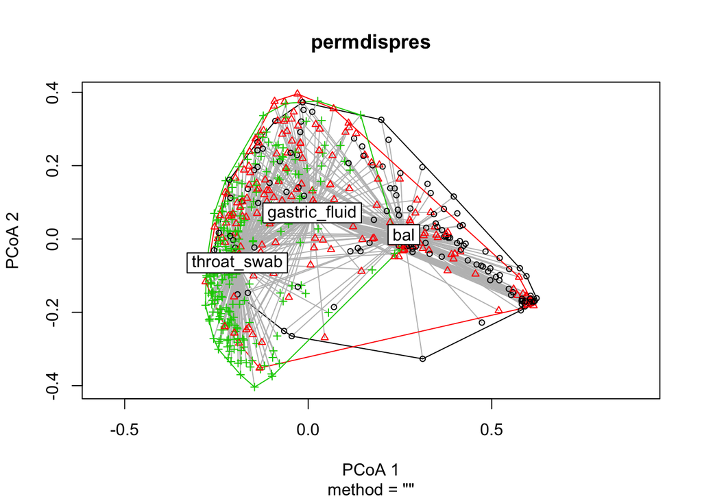

```r
# Plot some things it returns
plot(permdispres)
```

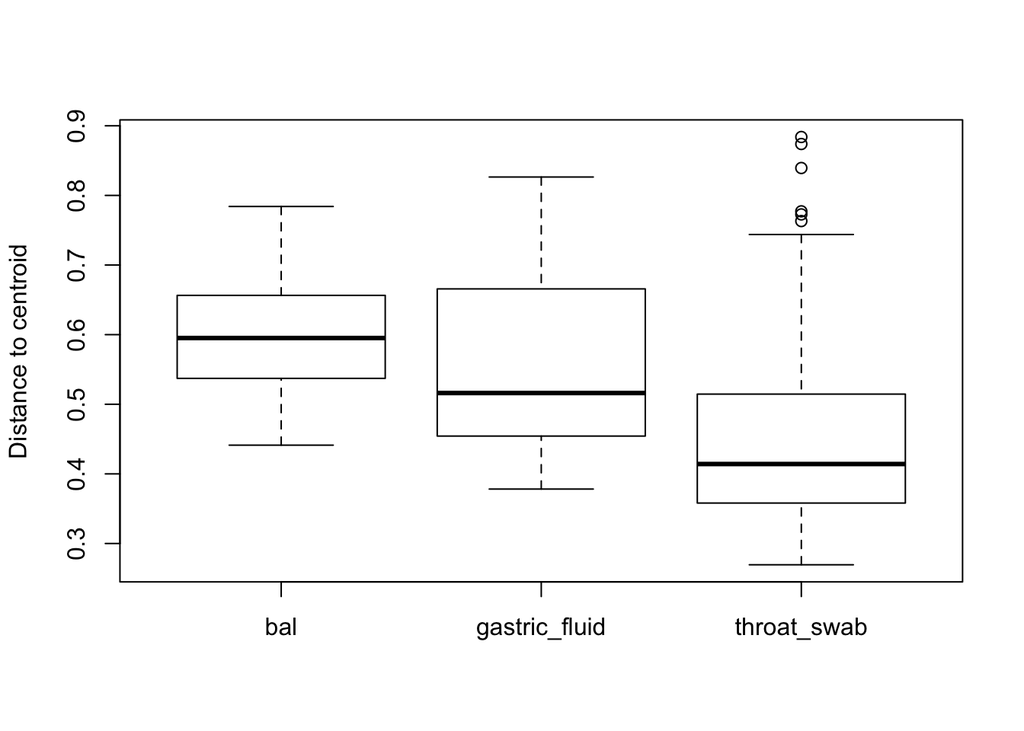

```r
boxplot(permdispres)
```

```r
# Save boxplot of dispersions

png(file="dispersions.png")
boxplot(permdispres)
dev.off()
```

```r
# And finally, test for significance
permutest(permdispres)
```

```
##
## Permutation test for homogeneity of multivariate dispersions
## Permutation: free
## Number of permutations: 999
##
## Response: Distances
##            Df Sum Sq Mean Sq      F N.Perm Pr(>F)
## Groups      2 2.5368 1.26840 93.333    999  0.001 ***
## Residuals 558 7.5833 0.01359
## ---
## Signif. codes:  0 '***' 0.001 '**' 0.01 '*' 0.05 '.' 0.1 ' ' 1
```

```r
permdispres.hsd <- TukeyHSD(permdispres)
permdispres.hsd
```

```
##   Tukey multiple comparisons of means
##     95% family-wise confidence level
##
## Fit: aov(formula = distances ~ group, data = df)
##
## $group
##                                 diff         lwr         upr     p adj
## gastric_fluid-bal         -0.0467203 -0.07814547 -0.01529514 0.0014895
## throat_swab-bal           -0.1579504 -0.18751905 -0.12838172 0.0000000
## throat_swab-gastric_fluid -0.1112301 -0.13798912 -0.08447105 0.0000000
```

From these results, it seems that data from all three communities is inconsistent with them having the same dispersion. It seems that gastric fluid and lung communities are slightly less different from each other (as we also saw from the beta diversity plots).

The most interesting takeaway, however, is that lungs and gastric fluid seem to be more dispersed than the throat swab (larger distance to centroid, as shown in the boxplot above).

## Permanova: what about centroids?

I think the adonis function does this, though not 100% sure on how to call it.

```r
permanovares <- adonis(as.dist(subjsd) ~ submeta$site)
permanovares$aov.tab
```

```
## Permutation: free
## Number of permutations: 999
##
## Terms added sequentially (first to last)
##
##               Df SumsOfSqs MeanSqs F.Model      R2 Pr(>F)
## submeta$site   2    18.686  9.3432  32.415 0.10409  0.001 ***
## Residuals    558   160.836  0.2882         0.89591
## Total        560   179.522                 1.00000
## ---
## Signif. codes:  0 '***' 0.001 '**' 0.01 '*' 0.05 '.' 0.1 ' ' 1
```

Hm, not sure if this is correct… let’s try one pairwise comparison I guess and see if it makes sense?

```r
# Do PERMANOVA between bal and gastric fluid
sites <- c("bal", "gastric_fluid")
keep_samples <- meta %>% filter(site %in% sites) %>% select(sample_id)
balgasjsd <- jsd[keep_samples$sample_id, keep_samples$sample_id]
balgasmeta <- meta[match(keep_samples$sample_id, meta$sample_id), ]
balgaspermanova <- adonis(as.dist(balgasjsd) ~ balgasmeta$site)
balgaspermanova$aov.tab
```

```
## Permutation: free
## Number of permutations: 999
##
## Terms added sequentially (first to last)
##
##                  Df SumsOfSqs MeanSqs F.Model      R2 Pr(>F)
## balgasmeta$site   1     3.604  3.6043  10.389 0.03243  0.001 ***
## Residuals       310   107.552  0.3469         0.96757
## Total           311   111.157                 1.00000
## ---
## Signif. codes:  0 '***' 0.001 '**' 0.01 '*' 0.05 '.' 0.1 ' ' 1
```

Eh, these results are different - but again, not sure how to interpret them. These seem less useful than the permdisp results, above! (Mostly because that one has a post-hoc test available, whereas this one does not seem to have one…)

**Is there a different way to check for homogeneity of centroids?**

## Try adonis with different contrast

```r
permanovares <- adonis(as.dist(subjsd) ~ submeta$site, contr.unordered="contr.helmert")
permanovares$aov.tab
```

```
## Permutation: free
## Number of permutations: 999
##
## Terms added sequentially (first to last)
##
##               Df SumsOfSqs MeanSqs F.Model      R2 Pr(>F)
## submeta$site   2    18.686  9.3432  32.415 0.10409  0.001 ***
## Residuals    558   160.836  0.2882         0.89591
## Total        560   179.522                 1.00000
## ---
## Signif. codes:  0 '***' 0.001 '**' 0.01 '*' 0.05 '.' 0.1 ' ' 1
```

## Some last notes

Before this is publication-worthy, I need to:

- re-do the analysis for the two sequencing batches separately and see if this changes the results significantly. If not, then I think just presenting them all together is probably fine. If it does, however, then I’ll need to think a bit harder… (Maybe just pick the larger of the two studies)
- make sure that no patients have two of the same site included here (this will be the case for some of the gastric and throat samples for sure!)